# Comparison between standard and WTT/DWT based approaches

## Contents

- 1. Setting up
  - 1.1 Imports
  - 1.2 Configure parameters
  - 1.3 Custom functions
  - 1.4 Load data
- 2. Classification
  - 2.1 Linear discriminant analysis
    - 2.1.1 Set up best performing parameters
    - 2.1.2 Computational experiment
    - 2.1.3 Sum up results
  - 2.2 Logistic regression
    - 2.2.1 Set up best performing parameters
    - 2.2.2 Computational experiment
    - 2.2.3 Sum up results
- 3. Agglomerative clustering
  - 3.1 Set up best performing parameters
  - 3.2 Computational experiment
  - 3.3 Sum up results
  - 3.4 Dendrograms

## 1. Setting up

- 1.1 Imports
- 1.2 Configure parameters
- 1.3 Custom functions
- 1.4 Load data

Return to contents

### 1.1 Imports

Required packages are: [numpy](http://www.numpy.org/), [scipy](https://www.scipy.org/), [matplotlib](https://matplotlib.org/index.html), [seaborn](https://seaborn.pydata.org), [scikit-learn](http://scikit-learn.org/stable/index.html), [pywt](http://pywavelets.readthedocs.io/en/latest/), [pandas](https://pandas.pydata.org/), [statmodels](https://www.statsmodels.org/stable/index.html).

Up to section $\quad$ Return to contents

```python
import sys
sys.path.append('../src/')
import os
import copy

import numpy as np
import scipy.interpolate
import pandas as pd

from ml_classes import baseLDA
from ml_classes import baseLR
from ml_classes import baseAC
from ml_classes import baseSC

from ml_classes import dwtLDA
from ml_classes import dwtLR
from ml_classes import dwtAC
from ml_classes import dwtSC

from ml_classes import wttLDA
from ml_classes import wttLR
from ml_classes import wttAC
from ml_classes import wttSC

from nonlinearity import sign_thresh, hos_thresh

from alg_stats import get_gscv_stats
from alg_stats import GridSearchCV_unsupervised

from files_io import ftirLoad

from sklearn.metrics import accuracy_score
from sklearn.metrics import fowlkes_mallows_score
from sklearn.metrics import adjusted_rand_score
from sklearn.metrics import adjusted_mutual_info_score

from sklearn.preprocessing import StandardScaler

from sklearn.cluster import SpectralClustering

from sklearn.model_selection import RepeatedStratifiedKFold
from sklearn.model_selection import cross_validate

from scipy.spatial import distance
from scipy.cluster import hierarchy
from sklearn.metrics.pairwise import pairwise_distances


import matplotlib.pyplot as plt
import seaborn as sns
from mpl_toolkits.mplot3d import Axes3D
from matplotlib.patches import Patch
%matplotlib inline
#%matplotlib notebook
```

### 1.2 Configure parameters

Up to section $\quad$ Return to contents

```python
# RepeatedKFoldCV configuration
n_splits = 4
n_repeats = 25

# number of parallel jobs for GridSearchCV
nJobsGSCV = 2

# limiter for FTIR spectrum (cm^{-1})
bandLim = 2000.

# random states for CV
random_state_cv_long = 235
random_state_cv_short = 578

species_colour_palette = [
    '#4B2929',
    '#8D5560',
    '#B43330',
    '#C96457',
    '#D6A592',
    '#9793B2',
    '#BBC1D1'
]
```

### 1.3 Custom functions

Up to section $\quad$ Return to contents

```python
### Upsampling data to be of length 2^d
def upsample_data_degree2(data, freq):
    newN = int(2**np.floor(1+np.log2(data.shape[0])))
    newFreq = np.linspace(freq[0], freq[-1], newN)
    Y = []
    for k in xrange(Nsamples):
        finterp = scipy.interpolate.interp1d(freq, data[:, k], 'cubic')
        Y.append( finterp(newFreq) )
    newT = np.array(Y).T
    return newFreq, newT

def extractLinkageMatrix(model):
    '''
    This is adoptation of the original implementation
    available at
    https://github.com/scikit-learn/scikit-learn/blob/
    70cf4a676caa2d2dad2e3f6e4478d64bcb0506f7/examples/
    cluster/plot_hierarchical_clustering_dendrogram.py
    '''
    children = model.children_
    distance = model.distance
    num_observations = 2+np.arange(children.shape[0])
    linkageMatrix = np.column_stack([
        children, distance, num_observations
    ])
    return linkageMatrix

def snsHCAplot(ac_model, X, column_colors=None):

    method = ac_model.linkage
    metric = ac_model.affinity
    R = ac_model.contrast(X.T)
    col_linkage = extractLinkageMatrix(ac_model.alg)

    R = pairwise_distances(R, Y=None, metric=metric)
    cm = sns.clustermap(
        R, pivot_kws=None, method=method,
        metric=metric, z_score=False, standard_scale=None,
        figsize=(10, 3), cbar_kws=None, row_cluster=False, col_cluster=True,
        row_linkage=None, col_linkage=col_linkage, row_colors=None, col_colors=column_colors,
        mask=np.ones(R.shape), cmap="mako"
    )
    cm.fig.delaxes(cm.fig.axes[-2])
    cm.fig.delaxes(cm.fig.axes[-1])

    cm.fig.axes[-1].yaxis.set_visible(False)

    cm.gs.set_height_ratios([0.12, 0.1, 0.05, 0.001])
    cm.gs.set_width_ratios([0.001, 0.001, 0.8])

    cm.gs.update()
    return cm
```

### 1.4 Load all necessary data

Up to section $\quad$ Return to contents

```python
data_dirname = '../data/'

## data with smaller resolution
fnms1 = [
    '08-07-2017-baselinecorrected.csv',
    '22-09-2017-baselinecorrected.csv'
]

## data with higher resolution
fnms2 = [
    '16-04-2018-baselinecorrected.csv',
    '18-04-2018-baselinecorrected.csv'
]

X1, labels1, freq = ftirLoad(fnms1, dirname=data_dirname)
X2, labels2, freq2 = ftirLoad(fnms2, dirname=data_dirname)

## v.2018 sampled more precisely; discretization points are exactly the same
X = np.hstack([X1[:-1, :], X2[::2, :]])
labels = labels1.tolist() + labels2.tolist()
labels = np.array(labels, dtype='i')
ind = np.where(freq <= bandLim)[0]
X, freq = X[ind], freq[ind]
Nsamples = X.shape[1]

# plain data for DWT
plainT = 0.01*X
# plain data for WTT (N=2^d)
freq2, plainT2 = upsample_data_degree2(plainT, freq)

# first order derivative data for DWT
dT = (plainT[2:] - plainT[:-2]) / (2.*np.reshape(freq[2:] - freq[:-2], [-1, 1]))
dFreq = freq[1:-1].copy()
# first order derivative data for WTT (N=2^d)
dFreq2, dT2 = upsample_data_degree2(dT, dFreq)

# second order derivative data for DWT
d2T = (plainT[2:] - 2*plainT[1:-1] + plainT[:-2]) / np.reshape(freq[2:] - freq[:-2], [-1, 1])**2.
d2Freq = freq[1:-1].copy()
# second order derivative data for WTT (N=2^d)
d2Freq2, d2T2 = upsample_data_degree2(d2T, d2Freq)

# generate CV indices
separator_long = RepeatedStratifiedKFold(
    n_splits=n_splits, n_repeats=n_repeats, random_state=random_state_cv_long
)
separator_short = RepeatedStratifiedKFold(
    n_splits=n_splits, n_repeats=1, random_state=random_state_cv_short
)

dummyX = np.empty(Nsamples)
train_indices_long, test_indices_long = [], []
for train_index, test_index in separator_long.split(dummyX, labels):
    train_indices_long.append(train_index)
    test_indices_long.append(test_index)
custom_cv_long = zip(train_indices_long, test_indices_long)

train_indices_short, test_indices_short = [], []
for train_index, test_index in separator_short.split(dummyX, labels):
    train_indices_short.append(train_index)
    test_indices_short.append(test_index)
#custom_cv_short = zip(train_indices_short[:n_splits], test_indices_short[:n_splits])


uni_labels = np.unique(labels)

species_dict = dict(zip(uni_labels, sns.color_palette(species_colour_palette, len(uni_labels))))
column_colors = map(lambda x: species_dict[x], labels)

species_filename = 'species.csv'

df_spec = pd.read_csv(data_dirname+species_filename, header=None)
label_plant_dict = df_spec.iloc[:, :2].to_dict()[1]
```

```
63 (1869, 63)
17 (3736, 17)
```

## 2. Classification

- 2.1 Linear discriminant analysis
  - 2.1.1 Set up best performing parameters
  - 2.1.2 Computational experiment
  - 2.1.3 Sum up results
- 2.2 Logistic regression
  - 2.2.1 Set up best performing parameters
  - 2.2.2 Computational experiment
  - 2.2.3 Sum up results

Return to contents

### 2.1 Linear discriminant analysis

- 2.1.1 Set up best performing parameters
- 2.1.2 Computational experiment
- 2.1.3 Sum up results

Up to section $\quad$ Return to contents

#### 2.1.1 Set up best performing parameters

Up to subsection $\quad$ Up to section $\quad$ Return to contents

```python
best_original_lda_plain_params = {
    'with_mean': False,
    'with_std': False,
    'with_abs': False
}
best_original_lda_d1_params = {
    'with_mean': False,
    'with_std': False,
    'with_abs': False

}
best_original_lda_d2_params = {
    'with_mean': False,
    'with_std': False,
    'with_abs': False
}


best_dwt_lda_plain_params = {
    'with_mean': False,
    'with_std': True,
    'with_abs': True,
    'th': 'hard',
    'tau': 1.00e-05,
    'wavelet_name': 'rbio3.1',
    'mode': 'zero',
    'nonlin': hos_thresh
}
best_dwt_lda_d1_params = {
    'with_mean': False,
    'with_std': True,
    'with_abs': False,
    'th': 'hard',
    'tau': 2.15e-02,
    'wavelet_name': 'bior2.6',
    'mode':  'smooth',
    'nonlin': hos_thresh
}
best_dwt_lda_d2_params = {
    'with_mean': False,
    'with_std': True,
    'with_abs': False,
    'th': 'soft',
    'tau': 4.64e-03,
    'wavelet_name': 'rbio3.7',
    'mode': 'periodization' ,
    'nonlin': hos_thresh
}



best_dwt_lda_plain_params_sign = {
    'with_mean': False,
    'with_std': False,
    'with_abs': True,
    'th': 'hard',
    'tau': 4.64e-05,
    'wavelet_name': 'rbio6.8',
    'mode': 'smooth',
    'nonlin': sign_thresh
}
best_dwt_lda_d1_params_sign = {
    'with_mean': True,
    'with_std': True,
    'with_abs': False,
    'th': 'hard',
    'tau': 1.00e-01,
    'wavelet_name': 'bior1.1',
    'mode':  'zero',
    'nonlin': sign_thresh
}
best_dwt_lda_d2_params_sign = {
    'with_mean': True,
    'with_std': True,
    'with_abs': False,
    'th': 'hard',
    'tau': 1.00e-01,
    'wavelet_name': 'rbio3.9',
    'mode': 'periodization' ,
    'nonlin': sign_thresh
}


'''
hard thresholding; with_abs=1, with_mean=0, with_std=1
                                       test     train
1st deriv. (rank=1, tau=2.15e-02)  0.826919  0.895325
2nd deriv. (rank=2, tau=1.00e-01)  0.746492  0.866613
original (rank=1, tau=1.00e-05)    0.923930  0.979151'''

best_wtt_lda_plain_params = {
    'with_mean': False,
    'with_std': True,
    'with_abs': True,
    'th': 'hard',
    'tau': 1.00e-05,
    'rank': 1,
    'nonlin': hos_thresh
}
best_wtt_lda_d1_params = {
    'with_mean': True,
    'with_std': True,
    'with_abs': False,
    'th': 'hard',
    'tau': 2.15e-02,
    'rank': 1,
    'nonlin': hos_thresh
}
best_wtt_lda_d2_params = {
    'with_mean': True,
    'with_std': True,
    'with_abs': False,
    'th': 'hard',
    'tau': 2.15e-02,
    'rank': 6,
    'nonlin': hos_thresh
}



best_wtt_lda_plain_params_sign = {
    'with_mean': True,
    'with_std': False,
    'with_abs': False,
    'th': 'hard',
    'tau': 2.15e-04,
    'rank': 4,
    'nonlin': sign_thresh
}

best_wtt_lda_d1_params_sign = {
    'with_mean': True,
    'with_std': True,
    'with_abs': False,
    'th': 'hard',
    'tau': 2.15e-02,
    'rank': 1,
    'nonlin': sign_thresh
}

best_wtt_lda_d2_params_sign = {
    'with_mean': True,
    'with_std': True,
    'with_abs': False,
    'th': 'hard',
    'tau': 1.00e-01,
    'rank': 4,
    'nonlin': sign_thresh
}
```

#### 2.1.2 Computational experiment

Up to subsection $\quad$ Up to section $\quad$ Return to contents

```python
# supress nasty sklearn warnings
def warn(*args, **kwargs):
    pass
import warnings
warnings.warn = warn
# thanks to https://stackoverflow.com/questions/32612180/eliminating-warnings-from-scikit-learn

result_lda_original_plain = cross_validate(
    baseLDA(**best_original_lda_plain_params), plainT.T, y=labels,
    groups=None, scoring=['accuracy', 'f1_weighted'], cv=custom_cv_long, n_jobs=nJobsGSCV,
    verbose=0, return_train_score=True
)
result_lda_original_d1 = cross_validate(
    baseLDA(**best_original_lda_d1_params), dT.T, y=labels,
    groups=None, scoring=['accuracy', 'f1_weighted'], cv=custom_cv_long, n_jobs=nJobsGSCV,
    verbose=0, return_train_score=True
)
result_lda_original_d2 = cross_validate(
    baseLDA(**best_original_lda_d2_params), d2T.T, y=labels,
    groups=None, scoring=['accuracy', 'f1_weighted'], cv=custom_cv_long, n_jobs=nJobsGSCV,
    verbose=0, return_train_score=True
)

result_lda_dwt_plain = cross_validate(
    dwtLDA(**best_dwt_lda_plain_params), plainT.T, y=labels,
    groups=None, scoring=['accuracy', 'f1_weighted'], cv=custom_cv_long, n_jobs=nJobsGSCV,
    verbose=0, return_train_score=True
)
result_lda_dwt_d1 = cross_validate(
    dwtLDA(**best_dwt_lda_d1_params), dT.T, y=labels,
    groups=None, scoring=['accuracy', 'f1_weighted'], cv=custom_cv_long, n_jobs=nJobsGSCV,
    verbose=0, return_train_score=True
)
result_lda_dwt_d2 = cross_validate(
    dwtLDA(**best_dwt_lda_d2_params), d2T.T, y=labels,
    groups=None, scoring=['accuracy', 'f1_weighted'], cv=custom_cv_long, n_jobs=nJobsGSCV,
    verbose=0, return_train_score=True
)

result_lda_dwt_plain_sign = cross_validate(
    dwtLDA(**best_dwt_lda_plain_params_sign), plainT.T, y=labels,
    groups=None, scoring=['accuracy', 'f1_weighted'], cv=custom_cv_long, n_jobs=nJobsGSCV,
    verbose=0, return_train_score=True
)
result_lda_dwt_d1_sign = cross_validate(
    dwtLDA(**best_dwt_lda_d1_params_sign), dT.T, y=labels,
    groups=None, scoring=['accuracy', 'f1_weighted'], cv=custom_cv_long, n_jobs=nJobsGSCV,
    verbose=0, return_train_score=True
)
result_lda_dwt_d2_sign = cross_validate(
    dwtLDA(**best_dwt_lda_d2_params_sign), d2T.T, y=labels,
    groups=None, scoring=['accuracy', 'f1_weighted'], cv=custom_cv_long, n_jobs=nJobsGSCV,
    verbose=0, return_train_score=True
)

result_lda_wtt_plain = cross_validate(
    wttLDA(**best_wtt_lda_plain_params), plainT2.T, y=labels,
    groups=None, scoring=['accuracy', 'f1_weighted'], cv=custom_cv_long, n_jobs=nJobsGSCV,
    verbose=0, return_train_score=True
)
result_lda_wtt_d1 = cross_validate(
    wttLDA(**best_wtt_lda_d1_params), dT2.T, y=labels,
    groups=None, scoring=['accuracy', 'f1_weighted'], cv=custom_cv_long, n_jobs=nJobsGSCV,
    verbose=0, return_train_score=True
)
result_lda_wtt_d2 = cross_validate(
    wttLDA(**best_wtt_lda_d2_params), d2T2.T, y=labels,
    groups=None, scoring=['accuracy', 'f1_weighted'], cv=custom_cv_long, n_jobs=nJobsGSCV,
    verbose=0, return_train_score=True
)

result_lda_wtt_plain_sign = cross_validate(
    wttLDA(**best_wtt_lda_plain_params_sign), plainT2.T, y=labels,
    groups=None, scoring=['accuracy', 'f1_weighted'], cv=custom_cv_long, n_jobs=nJobsGSCV,
    verbose=0, return_train_score=True
)
result_lda_wtt_d1_sign = cross_validate(
    wttLDA(**best_wtt_lda_d1_params_sign), dT2.T, y=labels,
    groups=None, scoring=['accuracy', 'f1_weighted'], cv=custom_cv_long, n_jobs=nJobsGSCV,
    verbose=0, return_train_score=True
)
result_lda_wtt_d2_sign = cross_validate(
    wttLDA(**best_wtt_lda_d2_params_sign), d2T2.T, y=labels,
    groups=None, scoring=['accuracy', 'f1_weighted'], cv=custom_cv_long, n_jobs=nJobsGSCV,
    verbose=0, return_train_score=True
)
```

#### 2.1.3 Sum up results

Up to subsection $\quad$ Up to section $\quad$ Return to contents

```python
df_dict = {}
df_dict['plain_accuracy'] = {
    'original (train)': np.mean(result_lda_original_plain[ 'train_accuracy']),
    'original (test)': np.mean(result_lda_original_plain[ 'test_accuracy']),

    'dwt (train)': np.mean(result_lda_dwt_plain[ 'train_accuracy']),
    'dwt (test)': np.mean(result_lda_dwt_plain[ 'test_accuracy']),

    'dwt+sgn (train)': np.mean(result_lda_dwt_plain_sign[ 'train_accuracy']),
    'dwt+sgn (test)': np.mean(result_lda_dwt_plain_sign[ 'test_accuracy']),

    'wtt (train)': np.mean(result_lda_wtt_plain[ 'train_accuracy']),
    'wtt (test)': np.mean(result_lda_wtt_plain[ 'test_accuracy']),

    'wtt+sgn (train)': np.mean(result_lda_wtt_plain_sign[ 'train_accuracy']),
    'wtt+sgn (test)': np.mean(result_lda_wtt_plain_sign[ 'test_accuracy'])
}
df_dict['d1_accuracy'] = {
    'original (train)': np.mean(result_lda_original_d1[ 'train_accuracy']),
    'original (test)': np.mean(result_lda_original_d1[ 'test_accuracy']),

    'dwt (train)': np.mean(result_lda_dwt_d1[ 'train_accuracy']),
    'dwt (test)': np.mean(result_lda_dwt_d1[ 'test_accuracy']),

    'dwt+sgn (train)': np.mean(result_lda_dwt_d1_sign[ 'train_accuracy']),
    'dwt+sgn (test)': np.mean(result_lda_dwt_d1_sign[ 'test_accuracy']),

    'wtt (train)': np.mean(result_lda_wtt_d1[ 'train_accuracy']),
    'wtt (test)': np.mean(result_lda_wtt_d1[ 'test_accuracy']),

    'wtt+sgn (train)': np.mean(result_lda_wtt_d1_sign[ 'train_accuracy']),
    'wtt+sgn (test)': np.mean(result_lda_wtt_d1_sign[ 'test_accuracy'])
}
df_dict['d2_accuracy'] = {
    'original (train)': np.mean(result_lda_original_d2[ 'train_accuracy']),
    'original (test)': np.mean(result_lda_original_d2[ 'test_accuracy']),

    'dwt (train)': np.mean(result_lda_dwt_d2[ 'train_accuracy']),
    'dwt (test)': np.mean(result_lda_dwt_d2[ 'test_accuracy']),

    'dwt+sgn (train)': np.mean(result_lda_dwt_d1_sign[ 'train_accuracy']),
    'dwt+sgn (test)': np.mean(result_lda_dwt_d1_sign[ 'test_accuracy']),

    'wtt (train)': np.mean(result_lda_wtt_d2[ 'train_accuracy']),
    'wtt (test)': np.mean(result_lda_wtt_d2[ 'test_accuracy']),

    'wtt+sgn (train)': np.mean(result_lda_wtt_d2_sign[ 'train_accuracy']),
    'wtt+sgn (test)': np.mean(result_lda_wtt_d2_sign[ 'test_accuracy'])
}
df_dict['plain_f1_weighted'] = {
    'original (train)': np.mean(result_lda_original_plain[ 'train_f1_weighted']),
    'original (test)': np.mean(result_lda_original_plain[ 'test_f1_weighted']),

    'dwt (train)': np.mean(result_lda_dwt_plain[ 'train_f1_weighted']),
    'dwt (test)': np.mean(result_lda_dwt_plain[ 'test_f1_weighted']),

    'wtt (train)': np.mean(result_lda_wtt_plain[ 'train_f1_weighted']),
    'wtt (test)': np.mean(result_lda_wtt_plain[ 'test_f1_weighted']),

    'dwt+sgn (train)': np.mean(result_lda_dwt_plain_sign[ 'train_f1_weighted']),
    'dwt+sgn (test)': np.mean(result_lda_dwt_plain_sign[ 'test_f1_weighted']),

    'wtt+sgn (train)': np.mean(result_lda_wtt_plain_sign[ 'train_f1_weighted']),
    'wtt+sgn (test)': np.mean(result_lda_wtt_plain_sign[ 'test_f1_weighted'])
}
df_dict['d1_f1_weighted'] = {
    'original (train)': np.mean(result_lda_original_d1[ 'train_f1_weighted']),
    'original (test)': np.mean(result_lda_original_d1[ 'test_f1_weighted']),

    'dwt (train)': np.mean(result_lda_dwt_d1[ 'train_f1_weighted']),
    'dwt (test)': np.mean(result_lda_dwt_d1[ 'test_f1_weighted']),

    'dwt+sgn (train)': np.mean(result_lda_dwt_d1_sign[ 'train_f1_weighted']),
    'dwt+sgn (test)': np.mean(result_lda_dwt_d1_sign[ 'test_f1_weighted']),

    'wtt (train)': np.mean(result_lda_wtt_d1[ 'train_f1_weighted']),
    'wtt (test)': np.mean(result_lda_wtt_d1[ 'test_f1_weighted']),

    'wtt+sgn (train)': np.mean(result_lda_wtt_d1_sign[ 'train_f1_weighted']),
    'wtt+sgn (test)': np.mean(result_lda_wtt_d1_sign[ 'test_f1_weighted'])
}
df_dict['d2_f1_weighted'] = {
    'original (train)': np.mean(result_lda_original_d2[ 'train_f1_weighted']),
    'original (test)': np.mean(result_lda_original_d2[ 'test_f1_weighted']),

    'dwt (train)': np.mean(result_lda_dwt_d2[ 'train_f1_weighted']),
    'dwt (test)': np.mean(result_lda_dwt_d2[ 'test_f1_weighted']),

    'dwt+sgn (train)': np.mean(result_lda_dwt_d1_sign[ 'train_f1_weighted']),
    'dwt+sgn (test)': np.mean(result_lda_dwt_d1_sign[ 'test_f1_weighted']),

    'wtt (train)': np.mean(result_lda_wtt_d2[ 'train_f1_weighted']),
    'wtt (test)': np.mean(result_lda_wtt_d2[ 'test_f1_weighted']),

    'wtt+sgn (train)': np.mean(result_lda_wtt_d2_sign[ 'train_f1_weighted']),
    'wtt+sgn (test)': np.mean(result_lda_wtt_d2_sign[ 'test_f1_weighted'])
}

df_out = pd.DataFrame(df_dict)
print df_out
```

```
                  d1_accuracy  d1_f1_weighted  d2_accuracy  d2_f1_weighted  \
dwt (test)           0.798208        0.786895     0.802190        0.788005
dwt (train)          0.948140        0.948950     0.954857        0.955533
dwt+sgn (test)       0.870787        0.865076     0.870787        0.865076
dwt+sgn (train)      0.850688        0.853637     0.850688        0.853637
original (test)      0.848942        0.841188     0.800051        0.786491
original (train)     0.982276        0.982384     0.942891        0.943773
wtt (test)           0.838255        0.829114     0.802517        0.790147
wtt (train)          0.962583        0.963085     0.943356        0.944171
wtt+sgn (test)       0.853229        0.847664     0.770224        0.759820
wtt+sgn (train)      0.843719        0.846818     0.794011        0.799346

                  plain_accuracy  plain_f1_weighted
dwt (test)              0.867241           0.860300
dwt (train)             0.991016           0.991051
dwt+sgn (test)          0.861196           0.855726
dwt+sgn (train)         0.901791           0.902449
original (test)         0.833425           0.826831
original (train)        1.000000           1.000000
wtt (test)              0.857964           0.848798
wtt (train)             0.982349           0.982499
wtt+sgn (test)          0.811749           0.803279
wtt+sgn (train)         0.960023           0.960488
```

## 2.2 Logistic regression

- 2.2.1 Set up best performing parameters
- 2.2.2 Computational experiment
- 2.2.3 Sum up results

Up to section $\quad$ Return to contents

#### 2.2.1 Set up best performing parameters

Up to subsection $\quad$ Up to section $\quad$ Return to contents

```python
best_original_lr_plain_params = {
    'with_abs': False,
    'with_mean': True,
    'with_std': True,
    'C': 1.0e+02,
    'penalty': 'l1',
    'solver': 'saga',
    'multi_class': 'ovr'
}
best_original_lr_d1_params = {
    'with_abs': False,
    'with_mean': True,
    'with_std': True,
    'C': 1.0e+01,
    'penalty': 'l2',
    'solver': 'saga',
    'multi_class': 'ovr'
}
best_original_lr_d2_params = {
    'with_abs': False,
    'with_mean': True,
    'with_std': True,
    'C': 1.0e+01,
    'penalty': 'l1',
    'solver': 'saga',
    'multi_class': 'ovr'
}


# with_abs=1, with_mean=0, with_std=1
# original (db3 zero [l1, C=1.0e+00, tau=1.00e-03])

# with_abs=1, with_mean=0, with_std=0
# original (bior1.5 zero [l2, C=1.0e-01, tau=1.00e-05])

# with_abs=0, with_mean=0, with_std=1
# original (db3 zero [l1, C=1.0e+00, tau=1.00e-03])

# with_abs=0, with_mean=0, with_std=0
# original (bior1.5 zero [l2, C=1.0e-01, tau=1.00e-05])
best_dwt_lr_plain_params = {
    'with_abs': False,
    'with_mean': False,
    'with_std': False,
    'th': 'hard',
    'tau': 1.00e-05,
    'wavelet_name': 'bior1.5',
    'mode':  'zero',
    'nonlin': sign_thresh,
    'C': 1.0e-01,
    'penalty': 'l2',
    'solver': 'saga',
    'multi_class': 'ovr'
}
# with_abs=1, with_mean=0, with_std=1
# 1st deriv. (sym4 zero [l1, C=1.0e+00, tau=1.00e-03])

# with_abs=0, with_mean=0, with_std=1
# 1st deriv. (sym5 zero [l2, C=1.0e-01, tau=4.64e-03])
best_dwt_lr_d1_params = {
    'with_abs': False,
    'with_mean': False,
    'with_std': True,
    'th': 'hard',
    'tau': 4.64e-03,
    'wavelet_name': 'sym5',
    'mode':  'zero',
    'nonlin': sign_thresh,
    'C': 1.0e-01,
    'penalty': 'l2',
    'solver': 'saga',
    'multi_class': 'ovr'
}
# with_abs=0, with_mean=0, with_std=1
# 2nd deriv. (coif16 zero [l1, C=1.0e+00, tau=1.00e-05])
best_dwt_lr_d2_params = {
    'with_abs': False,
    'with_mean': False,
    'with_std': True,
    'th': 'hard',
    'tau': 1.00e-05,
    'wavelet_name': 'coif16',
    'mode':  'zero',
    'nonlin': sign_thresh,
    'C': 1.0e+00,
    'penalty': 'l1',
    'solver': 'saga',
    'multi_class': 'ovr'
}



best_wtt_lr_plain_params = {
    'with_abs': True,
    'with_mean': False,
    'with_std': False,
    'C': 1.0e-01,
    'penalty': 'l2',
    'th': 'hard',
    'tau': 1.00e-05,
    'rank': 7,
    'solver': 'saga',
    'multi_class': 'ovr',
    'nonlin': sign_thresh
}
best_wtt_lr_d1_params = {
    'with_abs': False,
    'with_mean': False,
    'with_std': True,
    'C': 1.0e-01,
    'penalty': 'l2',
    'th': 'hard',
    'tau': 1.00e-01,
    'rank': 2,
    'solver': 'saga',
    'multi_class': 'ovr',
    'nonlin': sign_thresh
}

best_wtt_lr_d2_params = {
    'with_abs': False,
    'with_mean': False,
    'with_std': True,
    'C': 1.0e+00,
    'penalty': 'l1',
    'th': 'hard',
    'tau': 2.15e-04,
    'rank': 13, # there was an example with another parameters and worse accuracy (92 vs 96) but with rank 8
    'solver': 'saga',
    'multi_class': 'ovr',
    'nonlin': sign_thresh
}
```

#### 2.2.2 Computational experiment

Up to subsection $\quad$ Up to section $\quad$ Return to contents

```python
# supress nasty sklearn warnings
def warn(*args, **kwargs):
    pass
import warnings
warnings.warn = warn
# thanks to https://stackoverflow.com/questions/32612180/eliminating-warnings-from-scikit-learn

result_lr_original_plain = cross_validate(
    baseLR(**best_original_lr_plain_params), plainT.T, y=labels,
    groups=None, scoring=['accuracy', 'f1_weighted'], cv=custom_cv_long, n_jobs=nJobsGSCV,
    verbose=0, return_train_score=True
)
result_lr_original_d1 = cross_validate(
    baseLR(**best_original_lr_d1_params), dT.T, y=labels,
    groups=None, scoring=['accuracy', 'f1_weighted'], cv=custom_cv_long, n_jobs=nJobsGSCV,
    verbose=0, return_train_score=True
)
result_lr_original_d2 = cross_validate(
    baseLR(**best_original_lr_d2_params), d2T.T, y=labels,
    groups=None, scoring=['accuracy', 'f1_weighted'], cv=custom_cv_long, n_jobs=nJobsGSCV,
    verbose=0, return_train_score=True
)

result_lr_dwt_plain = cross_validate(
    dwtLR(**best_dwt_lr_plain_params), plainT.T, y=labels,
    groups=None, scoring=['accuracy', 'f1_weighted'], cv=custom_cv_long, n_jobs=nJobsGSCV,
    verbose=0, return_train_score=True
)
result_lr_dwt_d1 = cross_validate(
    dwtLR(**best_dwt_lr_d1_params), dT.T, y=labels,
    groups=None, scoring=['accuracy', 'f1_weighted'], cv=custom_cv_long, n_jobs=nJobsGSCV,
    verbose=0, return_train_score=True
)
result_lr_dwt_d2 = cross_validate(
    dwtLR(**best_dwt_lr_d2_params), d2T.T, y=labels,
    groups=None, scoring=['accuracy', 'f1_weighted'], cv=custom_cv_long, n_jobs=nJobsGSCV,
    verbose=0, return_train_score=True
)

result_lr_wtt_plain = cross_validate(
    wttLR(**best_wtt_lr_plain_params), plainT2.T, y=labels,
    groups=None, scoring=['accuracy', 'f1_weighted'], cv=custom_cv_long, n_jobs=nJobsGSCV,
    verbose=0, return_train_score=True
)
result_lr_wtt_d1 = cross_validate(
    wttLR(**best_wtt_lr_d1_params), dT2.T, y=labels,
    groups=None, scoring=['accuracy', 'f1_weighted'], cv=custom_cv_long, n_jobs=nJobsGSCV,
    verbose=0, return_train_score=True
)
result_lr_wtt_d2 = cross_validate(
    wttLR(**best_wtt_lr_d2_params), d2T2.T, y=labels,
    groups=None, scoring=['accuracy', 'f1_weighted'], cv=custom_cv_long, n_jobs=nJobsGSCV,
    verbose=0, return_train_score=True
)
```

#### 2.2.3 Sum up results

Up to subsection $\quad$ Up to section $\quad$ Return to contents

```python
df_dict = {}
df_dict['plain_accuracy'] = {
    'original (train)': np.mean(result_lr_original_plain[ 'train_accuracy']),
    'original (test)': np.mean(result_lr_original_plain[ 'test_accuracy']),
    'dwt (train)': np.mean(result_lr_dwt_plain[ 'train_accuracy']),
    'dwt (test)': np.mean(result_lr_dwt_plain[ 'test_accuracy']),
    'wtt (train)': np.mean(result_lr_wtt_plain[ 'train_accuracy']),
    'wtt (test)': np.mean(result_lr_wtt_plain[ 'test_accuracy']),
}
df_dict['d1_accuracy'] = {
    'original (train)': np.mean(result_lr_original_d1[ 'train_accuracy']),
    'original (test)': np.mean(result_lr_original_d1[ 'test_accuracy']),
    'dwt (train)': np.mean(result_lr_dwt_d1[ 'train_accuracy']),
    'dwt (test)': np.mean(result_lr_dwt_d1[ 'test_accuracy']),
    'wtt (train)': np.mean(result_lr_wtt_d1[ 'train_accuracy']),
    'wtt (test)': np.mean(result_lr_wtt_d1[ 'test_accuracy']),
}
df_dict['d2_accuracy'] = {
    'original (train)': np.mean(result_lr_original_d2[ 'train_accuracy']),
    'original (test)': np.mean(result_lr_original_d2[ 'test_accuracy']),
    'dwt (train)': np.mean(result_lr_dwt_d2[ 'train_accuracy']),
    'dwt (test)': np.mean(result_lr_dwt_d2[ 'test_accuracy']),
    'wtt (train)': np.mean(result_lr_wtt_d2[ 'train_accuracy']),
    'wtt (test)': np.mean(result_lr_wtt_d2[ 'test_accuracy']),
}
df_dict['plain_f1_weighted'] = {
    'original (train)': np.mean(result_lr_original_plain[ 'train_f1_weighted']),
    'original (test)': np.mean(result_lr_original_plain[ 'test_f1_weighted']),
    'dwt (train)': np.mean(result_lr_dwt_plain[ 'train_f1_weighted']),
    'dwt (test)': np.mean(result_lr_dwt_plain[ 'test_f1_weighted']),
    'wtt (train)': np.mean(result_lr_wtt_plain[ 'train_f1_weighted']),
    'wtt (test)': np.mean(result_lr_wtt_plain[ 'test_f1_weighted']),
}
df_dict['d1_f1_weighted'] = {
    'original (train)': np.mean(result_lr_original_d1[ 'train_f1_weighted']),
    'original (test)': np.mean(result_lr_original_d1[ 'test_f1_weighted']),
    'dwt (train)': np.mean(result_lr_dwt_d1[ 'train_f1_weighted']),
    'dwt (test)': np.mean(result_lr_dwt_d1[ 'test_f1_weighted']),
    'wtt (train)': np.mean(result_lr_wtt_d1[ 'train_f1_weighted']),
    'wtt (test)': np.mean(result_lr_wtt_d1[ 'test_f1_weighted']),
}
df_dict['d2_f1_weighted'] = {
    'original (train)': np.mean(result_lr_original_d2[ 'train_f1_weighted']),
    'original (test)': np.mean(result_lr_original_d2[ 'test_f1_weighted']),
    'dwt (train)': np.mean(result_lr_dwt_d2[ 'train_f1_weighted']),
    'dwt (test)': np.mean(result_lr_dwt_d2[ 'test_f1_weighted']),
    'wtt (train)': np.mean(result_lr_wtt_d2[ 'train_f1_weighted']),
    'wtt (test)': np.mean(result_lr_wtt_d2[ 'test_f1_weighted']),
}

df_out = pd.DataFrame(df_dict)
print df_out
```

```
                  d1_accuracy  d1_f1_weighted  d2_accuracy  d2_f1_weighted  \
dwt (test)           0.943500        0.940721     0.956055        0.954334
dwt (train)          1.000000        1.000000     1.000000        1.000000
original (test)      0.946319        0.943731     0.885057        0.877629
original (train)     0.987150        0.987117     0.985814        0.985763
wtt (test)           0.959311        0.957235     0.895957        0.892965
wtt (train)          1.000000        1.000000     1.000000        1.000000

                  plain_accuracy  plain_f1_weighted
dwt (test)              0.964607           0.962809
dwt (train)             1.000000           1.000000
original (test)         0.724356           0.712990
original (train)        0.883764           0.881791
wtt (test)              0.968796           0.967715
wtt (train)             1.000000           1.000000
```

## 3. Agglomerative clustering

- 3.1 Set up best performing parameters
- 3.2 Computational experiment
- 3.3 Sum up results
- 3.4 Dendrograms

Return to contents

#### 3.1 Set up best performing parameters

Up to section $\quad$ Return to contents

```python
n_clusters = len(np.unique(labels))

best_original_ac_plain_params = {
    'stsc_axis': 1,
    'with_abs': False,
    'with_mean': True,
    'with_std': True, # for l2; False for cosine
    'affinity': 'l2',
    'linkage': 'complete',
    'n_clusters': n_clusters
}
best_original_ac_d1_params = {
    'stsc_axis': 0,
    'with_abs': True,
    'with_mean': False,
    'with_std': True,
    'affinity': 'cosine',
    'linkage': 'complete',
    'n_clusters': n_clusters
}
best_original_ac_d2_params = {
    'stsc_axis': 0,
    'with_abs': True,
    'with_mean': False,
    'with_std': True,
    'affinity': 'cosine',
    'linkage': 'complete',
    'n_clusters': n_clusters
}

best_dwt_ac_plain_params = {
    'stsc_axis': 1,
    'with_abs': False,
    'with_mean': False,
    'with_std': True,
    'subtract': True,
    'th': 'soft',
    'mode': 'constant',
    'wavelet_name': 'sym4',
    'tau': 2.15e+00,
    'affinity': 'l1',
    'linkage': 'complete',
    'n_clusters': n_clusters,
    'nonlin': hos_thresh
}
best_dwt_ac_d1_params = {
    'stsc_axis': 1,
    'with_abs': False,
    'with_mean': False,
    'with_std': True,
    'subtract': True,
    'th': 'hard',
    'mode': 'periodic',
    'wavelet_name': 'bior1.5',
    'tau': 1.00e-05,
    'affinity': 'cosine',
    'linkage': 'complete',
    'n_clusters': n_clusters,
    'nonlin': hos_thresh
}
best_dwt_ac_d2_params = {
    'stsc_axis': 0,
    'with_abs': False,
    'with_mean': True,
    'with_std': True,
    'subtract': True,
    'th': 'hard',
    'mode': 'periodization',
    'wavelet_name': 'coif2',
    'tau': 1.00e-05,
    'affinity': 'cosine',
    'linkage': 'complete',
    'n_clusters': n_clusters,
    'nonlin': hos_thresh
}


best_wtt_ac_plain_params = {
    'stsc_axis': 1,
    'with_abs': False,
    'with_mean': True,
    'with_std': True,
    'subtract': True,
    'th': 'soft',
    'rank': 14,
    'tau': 4.64e-01,
    'affinity': 'cosine',
    'linkage': 'average',
    'n_clusters': n_clusters,
    'nonlin': hos_thresh
}
best_wtt_ac_d1_params = {
    'stsc_axis': 1,
    'with_abs': False,
    'with_mean': False,
    'with_std': True,
    'subtract': True,
    'th': 'hard',
    'rank': 15,
    'tau': 1.00e+01,
    'affinity': 'cosine',
    'linkage': 'complete',
    'n_clusters': n_clusters,
    'nonlin': hos_thresh
}
best_wtt_ac_d2_params = {
    'stsc_axis': 1,
    'with_abs': False,
    'with_mean': False,
    'with_std': True,
    'subtract': True,
    'th': 'soft',
    'rank': 18,
    'tau': 4.64e-01,
    'affinity': 'cosine',
    'linkage': 'complete',
    'n_clusters': n_clusters,
    'nonlin': hos_thresh
}
```

#### 3.2 Computational experiment

Up to section $\quad$ Return to contents

```python
ac_original_plain = baseAC(**best_original_ac_plain_params)
y_pred = ac_original_plain.fit_predict(plainT.T)
result_ac_original_plain = {
    'ami': adjusted_mutual_info_score(labels, y_pred),
    'ari': adjusted_rand_score(labels, y_pred),
    'fms': fowlkes_mallows_score(labels, y_pred)
}
ac_original_d1 = baseAC(**best_original_ac_d1_params)
y_pred = ac_original_d1.fit_predict(dT.T)
result_ac_original_d1 = {
    'ami': adjusted_mutual_info_score(labels, y_pred),
    'ari': adjusted_rand_score(labels, y_pred),
    'fms': fowlkes_mallows_score(labels, y_pred)
}
ac_original_d2 = baseAC(**best_original_ac_d2_params)
y_pred = ac_original_d2.fit_predict(d2T.T)
result_ac_original_d2 = {
    'ami': adjusted_mutual_info_score(labels, y_pred),
    'ari': adjusted_rand_score(labels, y_pred),
    'fms': fowlkes_mallows_score(labels, y_pred)
}

ac_dwt_plain = dwtAC(**best_dwt_ac_plain_params)
y_pred = ac_dwt_plain.fit_predict(plainT.T)
result_ac_dwt_plain = {
    'ami': adjusted_mutual_info_score(labels, y_pred),
    'ari': adjusted_rand_score(labels, y_pred),
    'fms': fowlkes_mallows_score(labels, y_pred)
}
ac_dwt_d1 = dwtAC(**best_dwt_ac_d1_params)
y_pred = ac_dwt_d1.fit_predict(dT.T)
result_ac_dwt_d1 = {
    'ami': adjusted_mutual_info_score(labels, y_pred),
    'ari': adjusted_rand_score(labels, y_pred),
    'fms': fowlkes_mallows_score(labels, y_pred)
}
ac_dwt_d2 = dwtAC(**best_dwt_ac_d2_params)
y_pred = ac_dwt_d2.fit_predict(d2T.T)
result_ac_dwt_d2 = {
    'ami': adjusted_mutual_info_score(labels, y_pred),
    'ari': adjusted_rand_score(labels, y_pred),
    'fms': fowlkes_mallows_score(labels, y_pred)
}

ac_wtt_plain = wttAC(**best_wtt_ac_plain_params)
y_pred = ac_wtt_plain.fit_predict(plainT2.T)
result_ac_wtt_plain = {
    'ami': adjusted_mutual_info_score(labels, y_pred),
    'ari': adjusted_rand_score(labels, y_pred),
    'fms': fowlkes_mallows_score(labels, y_pred)
}
ac_wtt_d1 = wttAC(**best_wtt_ac_d1_params)
y_pred = ac_wtt_d1.fit_predict(dT2.T)
result_ac_wtt_d1 = {
    'ami': adjusted_mutual_info_score(labels, y_pred),
    'ari': adjusted_rand_score(labels, y_pred),
    'fms': fowlkes_mallows_score(labels, y_pred)
}
ac_wtt_d2 = wttAC(**best_wtt_ac_d2_params)
y_pred = ac_wtt_d2.fit_predict(d2T2.T)
result_ac_wtt_d2 = {
    'ami': adjusted_mutual_info_score(labels, y_pred),
    'ari': adjusted_rand_score(labels, y_pred),
    'fms': fowlkes_mallows_score(labels, y_pred)
}
```

#### 3.3 Sum up results

Up to section $\quad$ Return to contents

```python
df_dict = {}
df_dict['plain'] = {
    'AMI_original': result_ac_original_plain['ami'],
    'ARI_original': result_ac_original_plain['ari'],
    'FMS_original': result_ac_original_plain['fms'],
}
df_dict['d1'] = {
    'AMI_original': result_ac_original_d1['ami'],
    'ARI_original': result_ac_original_d1['ari'],
    'FMS_original': result_ac_original_d1['fms'],
}
df_dict['d2'] = {
    'AMI_original': result_ac_original_d2['ami'],
    'ARI_original': result_ac_original_d2['ari'],
    'FMS_original': result_ac_original_d2['fms'],
}
df_out = pd.DataFrame(df_dict)
print df_out

df_dict['plain'] = {
    'AMI_dwt': result_ac_dwt_plain['ami'],
    'ARI_dwt': result_ac_dwt_plain['ari'],
    'FMS_dwt': result_ac_dwt_plain['fms'],
}
df_dict['d1'] = {
    'AMI_dwt': result_ac_dwt_d1['ami'],
    'ARI_dwt': result_ac_dwt_d1['ari'],
    'FMS_dwt': result_ac_dwt_d1['fms'],
}
df_dict['d2'] = {
    'AMI_dwt': result_ac_dwt_d2['ami'],
    'ARI_dwt': result_ac_dwt_d2['ari'],
    'FMS_dwt': result_ac_dwt_d2['fms'],
}
df_out = pd.DataFrame(df_dict)
print df_out

df_dict['plain'] = {
    'AMI_wtt': result_ac_wtt_plain['ami'],
    'ARI_wtt': result_ac_wtt_plain['ari'],
    'FMS_wtt': result_ac_wtt_plain['fms'],
}
df_dict['d1'] = {
    'AMI_wtt': result_ac_wtt_d1['ami'],
    'ARI_wtt': result_ac_wtt_d1['ari'],
    'FMS_wtt': result_ac_wtt_d1['fms'],
}
df_dict['d2'] = {
    'AMI_wtt': result_ac_wtt_d2['ami'],
    'ARI_wtt': result_ac_wtt_d2['ari'],
    'FMS_wtt': result_ac_wtt_d2['fms'],
}
df_out = pd.DataFrame(df_dict)
print df_out
```

```
                    d1        d2     plain
AMI_original  0.369695  0.264284  0.124947
ARI_original  0.262951  0.131763  0.067308
FMS_original  0.400124  0.369237  0.229087
               d1        d2     plain
AMI_dwt  0.400362  0.224691  0.616354
ARI_dwt  0.292247  0.147470  0.486650
FMS_dwt  0.469924  0.282801  0.572654
               d1        d2     plain
AMI_wtt  0.516239  0.438896  0.621657
ARI_wtt  0.386751  0.299306  0.501455
FMS_wtt  0.473671  0.413625  0.581892
```

#### 3.4 Dendrograms

Up to section $\quad$ Return to contents

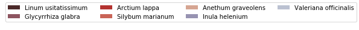

```
original signal
```

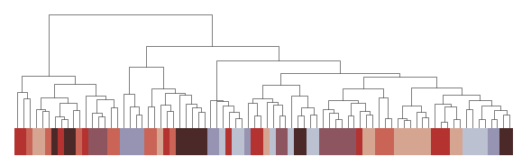

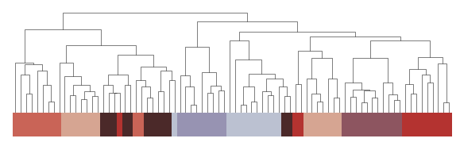

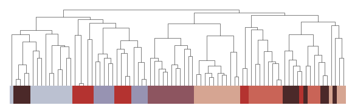

```
1st derivative
```

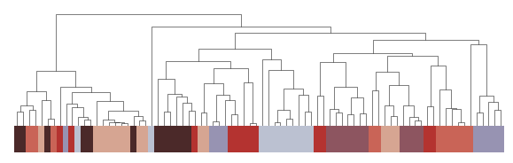

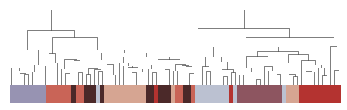

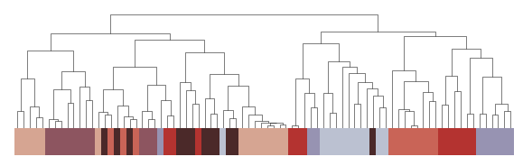

```
2nd derivative
```

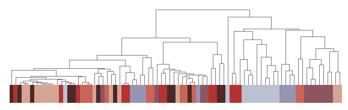

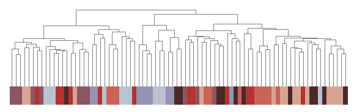

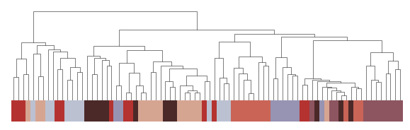

```python
results_dirname = '../results/hca/'
filename_base = 'hca_'


figleg = plt.figure(figsize=(3,0.5))
legend_elements = [
    Patch(facecolor=species_dict[x], label='%s' % (label_plant_dict[x]))
    for x in species_dict.keys()
]
uni_labels_named = [label_plant_dict[x] for x in species_dict.keys()]
# Create the figure
ax_leg = figleg.add_subplot(111)
figleg.legend(handles=legend_elements, labels=uni_labels_named, ncol=4)
ax_leg.xaxis.set_visible(False)
ax_leg.yaxis.set_visible(False)
ax_leg.set_frame_on(False)
plt.show()

print "original signal"
cm = snsHCAplot(
    ac_original_plain,
    plainT,
    column_colors
)
plt.show()

cm = snsHCAplot(
    ac_dwt_plain,
    plainT,
    column_colors
)
plt.show()

cm = snsHCAplot(
    ac_wtt_plain,
    plainT2,
    column_colors
)
plt.show()


print "1st derivative"
cm = snsHCAplot(
    ac_original_d1,
    dT,
    column_colors
)
plt.show()

cm = snsHCAplot(
    ac_dwt_d1,
    dT,
    column_colors
)
plt.show()

cm = snsHCAplot(
    ac_wtt_d1,
    dT2,
    column_colors
)
plt.show()


print "2nd derivative"
cm = snsHCAplot(
    ac_original_d2,
    d2T,
    column_colors
)
plt.show()

cm = snsHCAplot(
    ac_dwt_d2,
    d2T,
    column_colors
)

plt.show()
cm = snsHCAplot(
    ac_wtt_d2,
    d2T2,
    column_colors
)
plt.show()
```

Return to contents